# Reproducible Research: Peer Assessment 1

## Accessing the file via URL and downloading it (if necessary)

```r
## path <- "/home/benschnable/R/RepData_PeerAssessment1"
## if (!dir.exists(path)) {dir.create(path)}
## setwd(path)
## url <- "https://github.com/sixpacksound/RepData_PeerAssessment1/blob/master/activity.zip"
## download.file(url, destfile = "activity.zip")
```

## Loading and preprocessing the data (also loading libraries)

```r
unzip("activity.zip", junkpaths = TRUE)
act <- read.csv("activity.csv", na.strings = "NA")
library(dplyr)
library(ggplot2)
```

## What is mean total number of steps taken per day?

First, find the total number of steps taken each day:

```r
sumsteps <- aggregate(act$steps, by=list(act$date), sum)
names(sumsteps) <- c("Date", "Steps")
```

Then we can look at a histogram of the total steps each day:

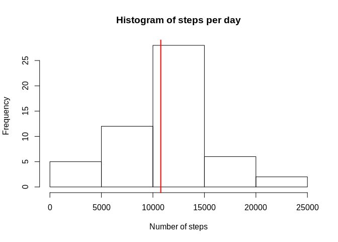

```r
hist(sumsteps$Steps, xlab = "Number of steps", main = "Histogram of steps per day")
abline(v = mean(sumsteps$Steps, na.rm = TRUE), lwd = 2, col = "red")
```

The red line shows the mean, and the calculated mean and median are:

```r
mean(sumsteps$Steps, na.rm = TRUE)
## [1] 10766.19
median(sumsteps$Steps, na.rm = TRUE)
## [1] 10765
```

## What is the average daily activity pattern?

To make a time series plot of average steps per time interval, we’ll use the dplyr package to group by interval and take the mean of the steps.

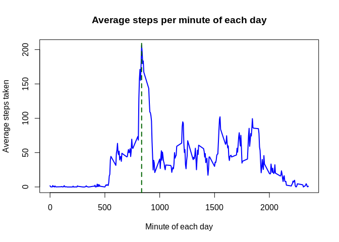

```r
tmp <- act %>%
        select(steps, interval) %>%
        group_by(interval) %>%
        summarize(mean = mean(steps, na.rm = TRUE))

plot(tmp$interval, tmp$mean, type="l", lwd = 2, col = "blue",
        xlab = "Minute of each day", ylab = "Average steps taken",
        main = "Average steps per minute of each day")
abline(v = tmp$interval[which.max(tmp$mean)], lty = 2, lwd = 2, col = "darkgreen")
```

The dashed line shows the interval when the most steps are taken (on average)

```r
tmp$interval[which.max(tmp$mean)]
```

```
## [1] 835
```

## Imputing missing values

First, we need to know how many rows of our dataframe have missing values.

```r
nrow(act[is.na(act), ])
```

```
## [1] 2304
```

We can use our previous dataframe *tmp* which has the average steps per interval, and create a new dataframe to match the dimensions of our dataframe with missing data.

```r
tmp2 <- sapply(tmp, rep.int, times = 61)
tmp2 <- as.data.frame(tmp2)
```

Then we can iterate over the rows of the initial dataframe. If the steps value is NA, then we will replace it with the calculated mean value for that particular interval.

```r
for (i in seq_along(act[ ,1])) {
        if (is.na(act$steps[i])) { act$steps[i] <- tmp2[i, 2]}
}
```

Now we have a complete dataframe *act* and we can re-run our earlier code to reproduce the histogram and calculate the mean and median.

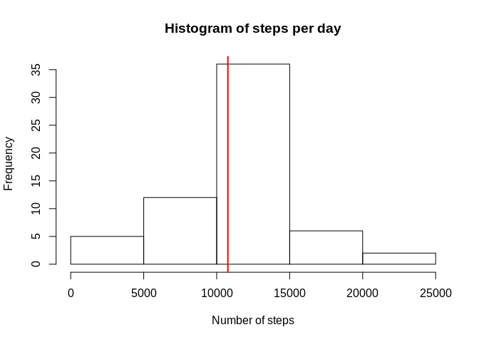

```r
newsteps <- aggregate(act$steps, by=list(act$date), sum)
names(newsteps) <- c("Date", "Steps")

hist(newsteps$Steps, xlab = "Number of steps", main = "Histogram of steps per day")
abline(v = mean(sumsteps$Steps, na.rm = TRUE), lwd = 2, col = "red")
```

```r
mean(newsteps$Steps)
## [1] 10766.19
median(newsteps$Steps)
## [1] 10766.19
```

We see very little change to the median value, and no change to the mean value. However, our distribution is now skewed much more heavily towards the center compared to the initial histogram.

## Are there differences in activity patterns between weekdays and weekends?

First, we will convert the **Date** column (currently a character vector) to a Date vector so we can add a column of weekdays to our dataframe. Then we will use those weekdays to create a two-level factor variable, separating our data into weekday and weekend labels.

```r
act$date <- as.Date.factor(act$date)
act$weekday <- weekdays(act$date)
act$daytype <- factor(act$weekday, levels = c("Monday", "Tuesday", "Wednesday",
                                              "Thursday", "Friday", "Saturday",
                                              "Sunday"), labels = c("Weekday",
                                              "Weekday", "Weekday", "Weekday",
                                              "Weekday", "Weekend", "Weekend"))
```

Then we can look at the average steps taken per interval of each of our new data labels. The process is similar to the one before, only this time we will group the data by both daytype and interval so we can see the two adjacent plots.

```r
tmp3 <- act %>%
        select(steps, interval, daytype) %>%
        group_by(daytype, interval) %>%
        summarize(mean = mean(steps))
```

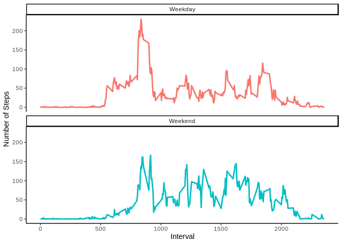

```r
g <- ggplot(tmp3, aes(interval, mean, color = daytype))
g + geom_line(lwd = 1) + facet_wrap(vars(daytype), nrow = 2, ncol = 1) +
        theme_classic() + theme(legend.position = "none") + labs(x = "Interval",
                                                            y = "Number of Steps")
```

Looking at the weekday and weekend data next to each other, we notice that there is one main peak (right around that 835 interval seen earlier) and a few scattered smaller peaks as the day goes on. On the weekend, there are more but lower peaks, indicating a more even dispersal of activity throughout Saturday and Sunday.